# WH_Exploit

## Lessons learned

### 4) The overall Top5 score (7.58) is very close to that of the OECD Top5 (7.578), which confirms the previous hypothesis: the majority of the countries in the overall Top5 are OECD countries.

### 5) There is a significant differential between the OECD Bottom5 score (5.6) and the overall Bottom5 score (3.138). This indicates that the Bottom5 countries are not OECD countries.

### 6) The Bottom5 score (3.138) outside the OECD is the same as the overall Bottom5 score. Bottom5 countries are not OECD countries.

```python
whr_19.head()
```

|  | Years | Country | HappinessRank | HappinessScore | Economy | Family | Health | Freedom | Generosity | Trust | DystopiaResidual | CountryCode | Region | IncomeGroup | OECD |
| --- | --- | --- | --- | --- | --- | --- | --- | --- | --- | --- | --- | --- | --- | --- | --- |
| 611 | 2019 | afghanistan | 154 | 3.20 | 0.35 | 0.52 | 0.36 | 0.00 | 0.16 | 0.03 | 1.79 | AFG | South Asia | Low income | 0 |
| 612 | 2019 | albania | 107 | 4.72 | 0.95 | 0.85 | 0.87 | 0.38 | 0.18 | 0.03 | 1.46 | ALB | Europe & Central Asia | Upper middle income | 0 |
| 613 | 2019 | united arab emirates | 21 | 6.83 | 1.50 | 1.31 | 0.83 | 0.60 | 0.26 | 0.18 | 2.15 | ARE | Middle East & North Africa | High income | 0 |
| 614 | 2019 | argentina | 47 | 6.09 | 1.09 | 1.43 | 0.88 | 0.47 | 0.07 | 0.05 | 2.09 | ARG | Latin America & Caribbean | Upper middle income | 0 |
| 615 | 2019 | armenia | 116 | 4.56 | 0.85 | 1.06 | 0.82 | 0.28 | 0.10 | 0.06 | 1.40 | ARM | Europe & Central Asia | Upper middle income | 0 |

sns.barplot(x="HappinessScore", y="Region", data=whr_19)

### Happiness Score's distribution

```python
version plotly
group_labels = ['2019'] # name of the dataset
hist_data = [whr_19['HappinessScore']]
fig = ff.create_distplot(hist_data, group_labels)
fig.show()
```

```python
# version seaborn
whr_19_dist = whr_19[['Region', 'HappinessScore']]
```

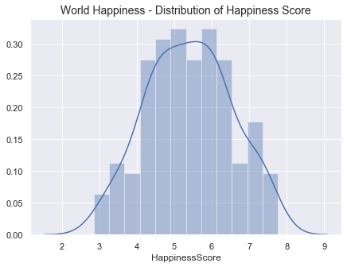

```python
fig = plt.figure(figsize=(7,5))
sns.set()
sns.distplot(whr_19_dist['HappinessScore'],bins=12);
plt.title('World Happiness - Distribution of Happiness Score', fontsize=14)
```

### Happiness Score's distribution per region

```python
# seaborn
# put the regions in columns
whr_19_pvt = whr_19_dist.pivot(columns='Region', values='HappinessScore')
```

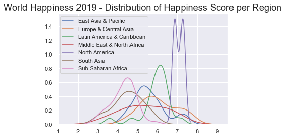

```python
# examine the distribution of kernel density estimation (KDE) factors
# y : probability of interval, distribution, density
sns.kdeplot(whr_19_pvt['East Asia & Pacific'])
sns.kdeplot(whr_19_pvt['Europe & Central Asia'])
sns.kdeplot(whr_19_pvt['Latin America & Caribbean'])
sns.kdeplot(whr_19_pvt['Middle East & North Africa'])
sns.kdeplot(whr_19_pvt['North America'])
sns.kdeplot(whr_19_pvt['South Asia'])
sns.kdeplot(whr_19_pvt['Sub-Saharan Africa'])

plt.title('World Happiness 2019 - Distribution of Happiness Score per Region', fontsize=18)
```

```python
# boxplot plotly
region_list = whr_19['Region'].unique()
plotly_boxp(region_list, whr_19, 'Region', 'HappinessScore', 'Happiness Score per Région 2019', 'Happiness Score', 'hs_region')
```

[interactive chart not shown]

## Lessons learned

### there is a great disparity between regions.

### • At the extremes are sub-Saharan Africa and North America.

### • Latin America & Caribbean stands out from other regions of the same level by the homogeneity of the score, between 5.43 (Q1) and 6.6 (Q4).

# 2. Is “Economy” the most decisive factor of the Happiness Score ?

```python
# Heatmaps reveal general pattern in the dataset
whr_19_corr = whr_19[factors_cols_full].corr()
```

```python
whr_19_corr
```

|  | HappinessScore | Economy | Family | Health | Freedom | Generosity | Trust | DystopiaResidual |
| --- | --- | --- | --- | --- | --- | --- | --- | --- |
| HappinessScore | 1.000000 | 0.791321 | 0.775694 | 0.782888 | 0.567543 | 0.067506 | 0.395067 | 0.478023 |
| Economy | 0.791321 | 1.000000 | 0.753853 | 0.834659 | 0.381010 | -0.087347 | 0.314668 | -0.032348 |
| Family | 0.775694 | 0.753853 | 1.000000 | 0.721577 | 0.450052 | -0.053630 | 0.192815 | 0.026448 |
| Health | 0.782888 | 0.834659 | 0.721577 | 1.000000 | 0.396282 | -0.030265 | 0.299175 | 0.003994 |
| Freedom | 0.567543 | 0.381010 | 0.450052 | 0.396282 | 1.000000 | 0.266376 | 0.445243 | 0.073951 |
| Generosity | 0.067506 | -0.087347 | -0.053630 | -0.030265 | 0.266376 | 1.000000 | 0.323174 | -0.057726 |
| Trust | 0.395067 | 0.314668 | 0.192815 | 0.299175 | 0.445243 | 0.323174 | 1.000000 | -0.006155 |
| DystopiaResidual | 0.478023 | -0.032348 | 0.026448 | 0.003994 | 0.073951 | -0.057726 | -0.006155 | 1.000000 |

```python
z_list = []
for index, rows in whr_19_corr.iterrows():
    # Create list for the current row
    my_list =[rows.HappinessScore, rows.Economy, rows.Family, rows.Health, rows.Freedom, rows.Generosity, rows.Trust, rows.DystopiaResidual ]
    # append the list to the final list
    z_list.append(my_list)
```

```python
z = z_list
x = factors_cols_full
y = factors_cols_full

z_text = np.around(z, decimals=2) # Only show rounded value (full value on hover)

fig = ff.create_annotated_heatmap(z, x=x, y=y, annotation_text=z_text, colorscale='bupu',
                                  hoverinfo='z')

# Make text size smaller
for i in range(len(fig.layout.annotations)):
    fig.layout.annotations[i].font.size = 10

fig.show()
plot(fig, filename=(r'C:\WPy64-3740\notebooks\Projets\world_happiness\app\templates\hs_htmap.html'), auto_open=False)
```

[interactive chart not shown]

```
'C:\\WPy64-3740\\notebooks\\Projets\\world_happiness\\app\\templates\\hs_htmap.html'
```

## Lessons learned

### Economy, Family & Health have the highest correlations with the Happiness Score, followed by Freedom.

### At the other end of the spectrum Generosity has a very low correlation (0.07). This means that this factor does not influence the Happiness Score.

```python
whr_19_generosity = whr_19.sort_values(by=['Generosity'], ascending=False)
```

```python
whr_19_generosity.head()
```

|  | Years | Country | HappinessRank | HappinessScore | Economy | Family | Health | Freedom | Generosity | Trust | DystopiaResidual | CountryCode | Region | IncomeGroup | OECD |
| --- | --- | --- | --- | --- | --- | --- | --- | --- | --- | --- | --- | --- | --- | --- | --- |
| 702 | 2019 | myanmar | 131 | 4.36 | 0.71 | 1.18 | 0.56 | 0.53 | 0.57 | 0.17 | 0.65 | MMR | East Asia & Pacific | Lower middle income | 0 |
| 669 | 2019 | indonesia | 92 | 5.19 | 0.93 | 1.20 | 0.66 | 0.49 | 0.50 | 0.03 | 1.38 | IDN | East Asia & Pacific | Lower middle income | 0 |
| 667 | 2019 | haiti | 147 | 3.60 | 0.32 | 0.69 | 0.45 | 0.03 | 0.42 | 0.11 | 1.58 | HTI | Latin America & Caribbean | Low income | 0 |
| 701 | 2019 | malta | 22 | 6.73 | 1.30 | 1.52 | 1.00 | 0.56 | 0.38 | 0.15 | 1.82 | MLT | Middle East & North Africa | High income | 0 |
| 630 | 2019 | bhutan | 95 | 5.08 | 0.81 | 1.32 | 0.60 | 0.46 | 0.37 | 0.17 | 1.35 | BTN | South Asia | Lower middle income | 0 |

```python
# the average by factor
whr_factors = whr_19[factors_cols]
mean_all = whr_factors.mean()
```

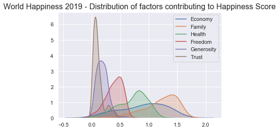

```python
# examine the distribution of kernel density estimation (KDE) factors
# y : probability of interval, distribution, density
sns.kdeplot(whr_19['Economy'], shade=True)
sns.kdeplot(whr_19['Family'], shade=True)
sns.kdeplot(whr_19['Health'], shade=True)
sns.kdeplot(whr_19['Freedom'], shade=True)
sns.kdeplot(whr_19['Generosity'], shade=True)
sns.kdeplot(whr_19['Trust'], shade=True)

plt.title('World Happiness 2019 - Distribution of factors contributing to Happiness Score', fontsize=16)
```

```python
whr_19.head()
```

|  | Years | Country | HappinessRank | HappinessScore | Economy | Family | Health | Freedom | Generosity | Trust | DystopiaResidual | CountryCode | Region | IncomeGroup | OECD |
| --- | --- | --- | --- | --- | --- | --- | --- | --- | --- | --- | --- | --- | --- | --- | --- |
| 611 | 2019 | afghanistan | 154 | 3.20 | 0.35 | 0.52 | 0.36 | 0.00 | 0.16 | 0.03 | 1.79 | AFG | South Asia | Low income | 0 |
| 612 | 2019 | albania | 107 | 4.72 | 0.95 | 0.85 | 0.87 | 0.38 | 0.18 | 0.03 | 1.46 | ALB | Europe & Central Asia | Upper middle income | 0 |
| 613 | 2019 | united arab emirates | 21 | 6.83 | 1.50 | 1.31 | 0.83 | 0.60 | 0.26 | 0.18 | 2.15 | ARE | Middle East & North Africa | High income | 0 |
| 614 | 2019 | argentina | 47 | 6.09 | 1.09 | 1.43 | 0.88 | 0.47 | 0.07 | 0.05 | 2.09 | ARG | Latin America & Caribbean | Upper middle income | 0 |
| 615 | 2019 | armenia | 116 | 4.56 | 0.85 | 1.06 | 0.82 | 0.28 | 0.10 | 0.06 | 1.40 | ARM | Europe & Central Asia | Upper middle income | 0 |

```python
# transforming factors into lines
whr_19_melt = pd.melt(whr_19, id_vars=['Country', 'CountryCode', 'Region', 'HappinessRank', 'HappinessScore'], value_vars=factors_cols)
```

```python
# rename the transformed columns
mapping = {'variable': 'Factors', 'value': 'Val'}
whr_19_melt = whr_19_melt.rename(mapping, axis=1)
```

```python
whr_19_melt.head()
```

|  | Country | CountryCode | Region | HappinessRank | HappinessScore | Factors | Val |
| --- | --- | --- | --- | --- | --- | --- | --- |
| 0 | afghanistan | AFG | South Asia | 154 | 3.20 | Economy | 0.35 |
| 1 | albania | ALB | Europe & Central Asia | 107 | 4.72 | Economy | 0.95 |
| 2 | united arab emirates | ARE | Middle East & North Africa | 21 | 6.83 | Economy | 1.50 |
| 3 | argentina | ARG | Latin America & Caribbean | 47 | 6.09 | Economy | 1.09 |
| 4 | armenia | ARM | Europe & Central Asia | 116 | 4.56 | Economy | 0.85 |

```python
# boxplot plotly
plotly_boxp(factors_cols_dr, whr_19_melt, 'Factors', 'Val', 'Factor distributions 2019', 'Score', 'fctrs_dst')
```

[interactive chart not shown]

## Lessons learned

### There is also a great disparity in factor values. Economy, Family and Health are the most predominant factors in the composition of the Happiness Score.

# 2. Factors that contributed to the Happiness Score

## b) Top5 & Bottom5

```python
# Top5 All
whr_t5, whr_b5 = tb5(whr_19, 'HappinessScore')

whr_t5_factors = whr_t5[factors_cols]
mean_t5 = whr_t5_factors.mean()

whr_b5_factors = whr_b5[factors_cols]
mean_b5 = whr_b5_factors.mean()
```

```python
# Top5 OECD
whr_t5_oecd, whr_b5_oecd = tb5(whr_19_oecd, 'HappinessScore')

whr_t5_factors_oecd = whr_t5_oecd[factors_cols]
mean_t5_oecd = whr_t5_factors_oecd.mean()

whr_b5_factors_oecd = whr_b5_oecd[factors_cols]
mean_b5_oecd = whr_b5_factors_oecd.mean()
```

```python
# Top5 out of OECD
whr_t5_noecd, whr_b5_noecd = tb5(whr_19_noecd, 'HappinessScore')
whr_t5_factors_noecd = whr_t5_noecd[factors_cols]
mean_t5_noecd = whr_t5_factors_noecd.mean()

whr_b5_factors_noecd = whr_b5_noecd[factors_cols]
mean_b5_noecd = whr_b5_factors_noecd.mean()
```

```python
# Top5 Economy
whr_t5_eco, whr_b5_eco = tb5(whr_19, 'Economy')
whr_t5_eco_factors = whr_t5_eco[factors_cols]
mean_t5_eco = whr_t5_eco_factors.mean()

whr_b5_eco_factors = whr_b5_eco[factors_cols]
mean_b5_eco = whr_b5_eco_factors.mean()
```

```python
mean_factors_t5 = pd.concat([mean_t5, mean_t5_oecd, mean_t5_noecd, mean_t5_eco], axis = 1)
mean_factors_t5_lst = ['Top5_all', 'Top5_OECD', 'Top5_NOECD', 'Top5_Eco']
mean_factors_t5.columns = mean_factors_t5_lst
```

```python
mean_factors_t5
```

|  | Top5_all | Top5_OECD | Top5_NOECD | Top5_Eco |
| --- | --- | --- | --- | --- |
| Economy | 1.398 | 1.412 | 1.202 | 1.572 |
| Family | 1.576 | 1.558 | 1.432 | 1.422 |
| Health | 1.010 | 1.014 | 0.914 | 0.970 |
| Freedom | 0.588 | 0.584 | 0.570 | 0.554 |
| Generosity | 0.268 | 0.250 | 0.262 | 0.248 |
| Trust | 0.312 | 0.356 | 0.124 | 0.286 |

```python
fig = go.Figure(data=[
    go.Bar(name='Economy', x=mean_factors_t5_lst, y=mean_factors_t5.loc['Economy',:])
    , go.Bar(name='Family', x=mean_factors_t5_lst, y=mean_factors_t5.loc['Family',:])
    , go.Bar(name='Health', x=mean_factors_t5_lst, y=mean_factors_t5.loc['Health',:])
    , go.Bar(name='Freedom', x=mean_factors_t5_lst, y=mean_factors_t5.loc['Freedom',:])
    , go.Bar(name='Generosity', x=mean_factors_t5_lst, y=mean_factors_t5.loc['Generosity',:])
    , go.Bar(name='Trust', x=mean_factors_t5_lst, y=mean_factors_t5.loc['Trust',:])
])

# Change the bar mode
fig.update_layout(barmode='stack')
fig.update_layout(title_text='Top 5 - Component factors of the Happiness Score 2019')
fig.show()
plot(fig, filename=(r'C:\WPy64-3740\notebooks\Projets\world_happiness\app\templates\fctrs_top5.html'), auto_open=False)
```

[interactive chart not shown]

```
'C:\\WPy64-3740\\notebooks\\Projets\\world_happiness\\app\\templates\\fctrs_top5.html'
```

### money can buy happiness :-)

```python
whr_19_economy = whr_19.sort_values(by=['Economy'], ascending=False)
```

```python
whr_19_economy.head()
```

|  | Years | Country | HappinessRank | HappinessScore | Economy | Family | Health | Freedom | Generosity | Trust | DystopiaResidual | CountryCode | Region | IncomeGroup | OECD |
| --- | --- | --- | --- | --- | --- | --- | --- | --- | --- | --- | --- | --- | --- | --- | --- |
| 725 | 2019 | qatar | 29 | 6.37 | 1.68 | 1.31 | 0.87 | 0.56 | 0.22 | 0.17 | 1.56 | QAT | Middle East & North Africa | High income | 0 |
| 693 | 2019 | luxembourg | 14 | 7.09 | 1.61 | 1.48 | 1.01 | 0.53 | 0.19 | 0.32 | 1.95 | LUX | Europe & Central Asia | High income | 1 |
| 731 | 2019 | singapore | 34 | 6.26 | 1.57 | 1.46 | 1.14 | 0.56 | 0.27 | 0.45 | 0.81 | SGP | East Asia & Pacific | High income | 0 |
| 685 | 2019 | kuwait | 51 | 6.02 | 1.50 | 1.32 | 0.81 | 0.49 | 0.14 | 0.10 | 1.66 | KWT | Middle East & North Africa | High income | 0 |
| 613 | 2019 | united arab emirates | 21 | 6.83 | 1.50 | 1.31 | 0.83 | 0.60 | 0.26 | 0.18 | 2.15 | ARE | Middle East & North Africa | High income | 0 |

```python
mean_factors_b5 = pd.concat([mean_b5, mean_b5_oecd, mean_b5_noecd, mean_b5_eco], axis = 1)
mean_factors_b5_lst = ['Bottom5_all', 'Bottom5_OECD', 'Bottom5_NOECD', 'Bottom5_eco']
mean_factors_b5.columns = mean_factors_b5_lst
```

```python
mean_factors_b5
```

|  | Bottom5_all | Bottom5_OECD | Bottom5_NOECD | Bottom5_eco |
| --- | --- | --- | --- | --- |
| Economy | 0.306 | 1.222 | 0.306 | 0.048 |
| Family | 0.540 | 1.356 | 0.540 | 0.640 |
| Health | 0.376 | 0.946 | 0.376 | 0.312 |
| Freedom | 0.244 | 0.286 | 0.244 | 0.330 |
| Generosity | 0.220 | 0.056 | 0.220 | 0.220 |
| Trust | 0.144 | 0.066 | 0.144 | 0.114 |

# 2. Factors that contributed to the Happiness Score

## c) Geographical regions

```python
happiness_R_economy = whr_19.pivot_table(values='Economy',index='Region')
happiness_R_family = whr_19.pivot_table(values='Family',index='Region')
happiness_R_health = whr_19.pivot_table(values='Health',index='Region')
happiness_R_freedom = whr_19.pivot_table(values='Freedom',index='Region')
happiness_R_generosity = whr_19.pivot_table(values='Generosity',index='Region')
happiness_R_trust = whr_19.pivot_table(values='Trust',index='Region')
happiness_R_dystopiaresidual = whr_19.pivot_table(values='DystopiaResidual',index='Region')
```

```python
happiness_R_factors = pd.concat([happiness_R_economy, happiness_R_family, happiness_R_health, happiness_R_freedom, happiness_R_generosity, happiness_R_trust, happiness_R_dystopiaresidual], axis = 1)
```

```python
happiness_RT_factors = happiness_R_factors.transpose()
```

```python
happiness_RT_factors
```

| Region | East Asia & Pacific | Europe & Central Asia | Latin America & Caribbean | Middle East & North Africa | North America | South Asia | Sub-Saharan Africa |
| --- | --- | --- | --- | --- | --- | --- | --- |
| Economy | 1.067500 | 1.158163 | 0.9085 | 1.087222 | 1.400 | 0.651429 | 0.447692 |
| Family | 1.306250 | 1.395102 | 1.3335 | 1.152222 | 1.485 | 0.990000 | 0.916923 |
| Health | 0.850000 | 0.890000 | 0.8175 | 0.767222 | 0.955 | 0.617143 | 0.408205 |
| Freedom | 0.496875 | 0.401429 | 0.4395 | 0.344444 | 0.515 | 0.387143 | 0.336667 |
| Generosity | 0.262500 | 0.168367 | 0.1430 | 0.173333 | 0.285 | 0.235714 | 0.186923 |
| Trust | 0.150000 | 0.125918 | 0.0750 | 0.110556 | 0.220 | 0.095714 | 0.093333 |
| DystopiaResidual | 1.477500 | 1.942041 | 2.2280 | 1.710556 | 2.230 | 1.557143 | 1.910256 |

```python
happiness_RT_lst = happiness_RT_factors.columns.values.tolist()
```

```python
happiness_RT_lst
```

```
['East Asia & Pacific',
 'Europe & Central Asia',
 'Latin America & Caribbean',
 'Middle East & North Africa',
 'North America',
 'South Asia',
 'Sub-Saharan Africa']
```

```python
fig = go.Figure(data=[
    go.Bar(name='Economy', x=happiness_RT_lst, y=happiness_RT_factors.loc['Economy',:])
    , go.Bar(name='Family', x=happiness_RT_lst, y=happiness_RT_factors.loc['Family',:])
    , go.Bar(name='Health', x=happiness_RT_lst, y=happiness_RT_factors.loc['Health',:])
    , go.Bar(name='Freedom', x=happiness_RT_lst, y=happiness_RT_factors.loc['Freedom',:])
    , go.Bar(name='Generosity', x=happiness_RT_lst, y=happiness_RT_factors.loc['Generosity',:])
    , go.Bar(name='Trust', x=happiness_RT_lst, y=happiness_RT_factors.loc['Trust',:])
    , go.Bar(name='DystopiaResidual', x=happiness_RT_lst, y=happiness_RT_factors.loc['DystopiaResidual',:])
])

# Change the bar mode
fig.update_layout(barmode='stack')
fig.update_layout(title_text='Région - Component factors of the Happiness Score 2019')
fig.show()
plot(fig, filename=(r'C:\WPy64-3740\notebooks\Projets\world_happiness\app\templates\fctrs_region.html'), auto_open=False)
```

[interactive chart not shown]

```
'C:\\WPy64-3740\\notebooks\\Projets\\world_happiness\\app\\templates\\fctrs_region.html'
```

### Sub-Saharan Africa, the region with the lowest Happiness Score, has the lowest Economy & Health scores.

### 3. Is the World Bank's "Income Share" index correlated with Happiness Score ?

```python
selected_countries = ['Togo','Switzerland','France','China','Luxembourg']
selected_indicators = ['SI.DST.FRST.20','SI.DST.02ND.20','SI.DST.03RD.20','SI.DST.04TH.20','SI.DST.05TH.20']
selected_year = ['2015']
```

```python
income_share = indicators[indicators["IndicatorCode"].isin(selected_indicators) & indicators["CountryName"].isin(selected_countries) & indicators["Years"].isin(selected_year)]
```

```python
income_share_slim = income_share[['CountryName', 'IndicatorCode', 'Val']]
```

```python
income_share_TGO = income_share_slim[income_share_slim['CountryName']=='Togo']
income_share_CHE = income_share_slim[income_share_slim['CountryName']=='Switzerland']
income_share_FRA = income_share_slim[income_share_slim['CountryName']=='France']
income_share_CHN = income_share_slim[income_share_slim['CountryName']=='China']
income_share_LUX = income_share_slim[income_share_slim['CountryName']=='Luxembourg']
```

```python
income_share_TGO.rename(columns={'Val':'Togo'}, inplace=True)
income_share_CHE.rename(columns={'Val':'Switzerland'}, inplace=True)
income_share_FRA.rename(columns={'Val':'France'}, inplace=True)
income_share_CHN.rename(columns={'Val':'China'}, inplace=True)
income_share_LUX.rename(columns={'Val':'Luxembourg'}, inplace=True)
```

```python
income_share_TGO = income_share_TGO[['IndicatorCode', 'Togo']]
income_share_CHE = income_share_CHE[['IndicatorCode', 'Switzerland']]
income_share_FRA = income_share_FRA[['IndicatorCode', 'France']]
income_share_CHN = income_share_CHN[['IndicatorCode', 'China']]
income_share_LUX = income_share_LUX[['IndicatorCode', 'Luxembourg']]
```

```python
income_share_1 = pd.merge(income_share_TGO, income_share_CHE, on='IndicatorCode')
income_share_2 = pd.merge(income_share_1, income_share_FRA, on='IndicatorCode')
income_share_3 = pd.merge(income_share_2, income_share_CHN, on='IndicatorCode')
income_share_4 = pd.merge(income_share_3, income_share_LUX, on='IndicatorCode')
```

```python
income_share_4.set_index('IndicatorCode',  inplace = True)
```

```python
income_share_4
```

| IndicatorCode | Togo | Switzerland | France | China | Luxembourg |
| --- | --- | --- | --- | --- | --- |
| SI.DST.02ND.20 | 9.5 | 12.5 | 12.8 | 10.6 | 12.1 |
| SI.DST.03RD.20 | 14.4 | 16.8 | 16.7 | 15.3 | 16.7 |
| SI.DST.04TH.20 | 22.4 | 22.6 | 21.7 | 22.3 | 23.1 |
| SI.DST.05TH.20 | 48.6 | 40.2 | 40.9 | 45.4 | 41.0 |
| SI.DST.FRST.20 | 5.0 | 7.8 | 7.9 | 6.4 | 7.2 |

```python
idx_order = ['SI.DST.FRST.20','SI.DST.02ND.20','SI.DST.03RD.20','SI.DST.04TH.20', 'SI.DST.05TH.20']
```

```python
income_share_4.reindex(idx_order)
```

| IndicatorCode | Togo | Switzerland | France | China | Luxembourg |
| --- | --- | --- | --- | --- | --- |
| SI.DST.FRST.20 | 5.0 | 7.8 | 7.9 | 6.4 | 7.2 |
| SI.DST.02ND.20 | 9.5 | 12.5 | 12.8 | 10.6 | 12.1 |
| SI.DST.03RD.20 | 14.4 | 16.8 | 16.7 | 15.3 | 16.7 |
| SI.DST.04TH.20 | 22.4 | 22.6 | 21.7 | 22.3 | 23.1 |
| SI.DST.05TH.20 | 48.6 | 40.2 | 40.9 | 45.4 | 41.0 |

```python
fig = go.Figure(data=[
    go.Bar(name='Income Share Lowest 20%', x=selected_countries, y=income_share_4.loc['SI.DST.FRST.20',:])
    , go.Bar(name='Income Share Second 20%', x=selected_countries, y=income_share_4.loc['SI.DST.02ND.20',:])
    , go.Bar(name='Income Share Third 20%', x=selected_countries, y=income_share_4.loc['SI.DST.03RD.20',:])
    , go.Bar(name='Income Share Fourth 20%', x=selected_countries, y=income_share_4.loc['SI.DST.04TH.20',:])
    , go.Bar(name='Income Share Highest 20%', x=selected_countries, y=income_share_4.loc['SI.DST.05TH.20',:])
])

# Change the bar mode
fig.update_layout(
    title='Income sharing 2015',
    xaxis_tickfont_size=14,
    yaxis=dict(
        title='Pourcentage',
        titlefont_size=16,
        tickfont_size=14,
    ),
    barmode='stack',
    bargap=0.15, # gap between bars of adjacent location coordinates.
    bargroupgap=0.1 # gap between bars of the same location coordinate.
)
fig.show()
plot(fig, filename=(r'C:\WPy64-3740\notebooks\Projets\world_happiness\app\templates\income_share.html'), auto_open=False)
```

[interactive chart not shown]

```
'C:\\WPy64-3740\\notebooks\\Projets\\world_happiness\\app\\templates\\income_share.html'
```

### There are no notable differences between Switzerland (1st), Luxembourg (17th) and France (30th).

```python
# choose the index to keep and delete the lines with empty values
inc_shr = indicators[indicators['IndicatorCode'] == 'SI.DST.FRST.20'].dropna()
```

```python
# keep only the value of the most recent year not empty
inc_shr = inc_shr.groupby(["CountryCode"], as_index=False).max()
# ind_shr = ind_shr.sort_values('Years').drop_duplicates(["CountryCode"],keep='last')
```

```python
inc_shr.shape
```

```
(93, 6)
```

```python
inc_shr.sort_values('Val')
```

|  | CountryCode | CountryName | IndicatorName | IndicatorCode | Years | Val |
| --- | --- | --- | --- | --- | --- | --- |
| 61 | NAM | Namibia | Income share held by lowest 20% | SI.DST.FRST.20 | 2015 | 2.8 |
| 92 | ZMB | Zambia | Income share held by lowest 20% | SI.DST.FRST.20 | 2015 | 2.9 |
| 48 | LCA | St. Lucia | Income share held by lowest 20% | SI.DST.FRST.20 | 2016 | 3.1 |
| 4 | BEN | Benin | Income share held by lowest 20% | SI.DST.FRST.20 | 2015 | 3.2 |
| 65 | PAN | Panama | Income share held by lowest 20% | SI.DST.FRST.20 | 2017 | 3.4 |
| 36 | HND | Honduras | Income share held by lowest 20% | SI.DST.FRST.20 | 2017 | 3.6 |
| 8 | BRA | Brazil | Income share held by lowest 20% | SI.DST.FRST.20 | 2017 | 3.6 |
| 10 | BWA | Botswana | Income share held by lowest 20% | SI.DST.FRST.20 | 2015 | 3.9 |
| 15 | COL | Colombia | Income share held by lowest 20% | SI.DST.FRST.20 | 2017 | 4.1 |
| 7 | BOL | Bolivia | Income share held by lowest 20% | SI.DST.FRST.20 | 2017 | 4.1 |
| 16 | CRI | Costa Rica | Income share held by lowest 20% | SI.DST.FRST.20 | 2017 | 4.4 |
| 70 | PRY | Paraguay | Income share held by lowest 20% | SI.DST.FRST.20 | 2017 | 4.6 |
| 66 | PER | Peru | Income share held by lowest 20% | SI.DST.FRST.20 | 2017 | 4.7 |
| 23 | ECU | Ecuador | Income share held by lowest 20% | SI.DST.FRST.20 | 2017 | 4.7 |
| 33 | GHA | Ghana | Income share held by lowest 20% | SI.DST.FRST.20 | 2016 | 4.7 |
| 76 | SRB | Serbia | Income share held by lowest 20% | SI.DST.FRST.20 | 2015 | 4.8 |
| 54 | MEX | Mexico | Income share held by lowest 20% | SI.DST.FRST.20 | 2016 | 4.9 |
| 80 | TGO | Togo | Income share held by lowest 20% | SI.DST.FRST.20 | 2015 | 5.0 |
| 89 | USA | United States | Income share held by lowest 20% | SI.DST.FRST.20 | 2016 | 5.0 |
| 22 | DOM | Dominican Republic | Income share held by lowest 20% | SI.DST.FRST.20 | 2016 | 5.0 |
| 72 | ROU | Romania | Income share held by lowest 20% | SI.DST.FRST.20 | 2015 | 5.1 |
| 0 | ARG | Argentina | Income share held by lowest 20% | SI.DST.FRST.20 | 2017 | 5.1 |
| 12 | CHL | Chile | Income share held by lowest 20% | SI.DST.FRST.20 | 2017 | 5.2 |
| 42 | ISR | Israel | Income share held by lowest 20% | SI.DST.FRST.20 | 2016 | 5.2 |
| 20 | DJI | Djibouti | Income share held by lowest 20% | SI.DST.FRST.20 | 2017 | 5.4 |
| 55 | MKD | North Macedonia | Income share held by lowest 20% | SI.DST.FRST.20 | 2015 | 5.6 |
| 85 | TUR | Turkey | Income share held by lowest 20% | SI.DST.FRST.20 | 2016 | 5.7 |
| 14 | CIV | Cote d'Ivoire | Income share held by lowest 20% | SI.DST.FRST.20 | 2015 | 5.7 |
| 67 | PHL | Philippines | Income share held by lowest 20% | SI.DST.FRST.20 | 2015 | 5.7 |
| 25 | ESP | Spain | Income share held by lowest 20% | SI.DST.FRST.20 | 2015 | 5.8 |
| ... | ... | ... | ... | ... | ... | ... |
| 26 | EST | Estonia | Income share held by lowest 20% | SI.DST.FRST.20 | 2015 | 7.5 |
| 38 | HUN | Hungary | Income share held by lowest 20% | SI.DST.FRST.20 | 2015 | 7.8 |
| 11 | CHE | Switzerland | Income share held by lowest 20% | SI.DST.FRST.20 | 2015 | 7.8 |
| 84 | TUN | Tunisia | Income share held by lowest 20% | SI.DST.FRST.20 | 2015 | 7.8 |
| 19 | DEU | Germany | Income share held by lowest 20% | SI.DST.FRST.20 | 2015 | 7.8 |
| 17 | CYP | Cyprus | Income share held by lowest 20% | SI.DST.FRST.20 | 2015 | 7.9 |
| 2 | AUT | Austria | Income share held by lowest 20% | SI.DST.FRST.20 | 2015 | 7.9 |
| 29 | FRA | France | Income share held by lowest 20% | SI.DST.FRST.20 | 2015 | 7.9 |
| 40 | IRL | Ireland | Income share held by lowest 20% | SI.DST.FRST.20 | 2015 | 8.0 |
| 58 | MNG | Mongolia | Income share held by lowest 20% | SI.DST.FRST.20 | 2016 | 8.0 |
| 79 | SWE | Sweden | Income share held by lowest 20% | SI.DST.FRST.20 | 2015 | 8.2 |
| 1 | ARM | Armenia | Income share held by lowest 20% | SI.DST.FRST.20 | 2017 | 8.4 |
| 77 | SVK | Slovak Republic | Income share held by lowest 20% | SI.DST.FRST.20 | 2015 | 8.5 |
| 56 | MLT | Malta | Income share held by lowest 20% | SI.DST.FRST.20 | 2015 | 8.5 |
| 5 | BGD | Bangladesh | Income share held by lowest 20% | SI.DST.FRST.20 | 2016 | 8.6 |
| 3 | BEL | Belgium | Income share held by lowest 20% | SI.DST.FRST.20 | 2015 | 8.6 |
| 64 | PAK | Pakistan | Income share held by lowest 20% | SI.DST.FRST.20 | 2015 | 8.9 |
| 62 | NLD | Netherlands | Income share held by lowest 20% | SI.DST.FRST.20 | 2015 | 8.9 |
| 63 | NOR | Norway | Income share held by lowest 20% | SI.DST.FRST.20 | 2015 | 9.0 |
| 24 | EGY | Egypt, Arab Rep. | Income share held by lowest 20% | SI.DST.FRST.20 | 2015 | 9.1 |
| 28 | FIN | Finland | Income share held by lowest 20% | SI.DST.FRST.20 | 2015 | 9.4 |
| 21 | DNK | Denmark | Income share held by lowest 20% | SI.DST.FRST.20 | 2015 | 9.4 |
| 91 | XKX | Kosovo | Income share held by lowest 20% | SI.DST.FRST.20 | 2017 | 9.5 |
| 78 | SVN | Slovenia | Income share held by lowest 20% | SI.DST.FRST.20 | 2015 | 9.6 |
| 18 | CZE | Czech Republic | Income share held by lowest 20% | SI.DST.FRST.20 | 2015 | 9.7 |
| 6 | BLR | Belarus | Income share held by lowest 20% | SI.DST.FRST.20 | 2017 | 9.9 |
| 53 | MDA | Moldova | Income share held by lowest 20% | SI.DST.FRST.20 | 2017 | 10.0 |
| 44 | KAZ | Kazakhstan | Income share held by lowest 20% | SI.DST.FRST.20 | 2017 | 10.0 |
| 46 | KGZ | Kyrgyz Republic | Income share held by lowest 20% | SI.DST.FRST.20 | 2017 | 10.0 |
| 87 | UKR | Ukraine | Income share held by lowest 20% | SI.DST.FRST.20 | 2016 | 10.1 |

93 rows × 6 columns

```python
plotly_chorop(inc_shr, 'CountryName', 'delta', 'Val', 'lowest 20%', '% of income held by the poorest 20% of the population', 'hammer', 'IncomeShareByTheLowest')
```

[interactive chart not shown]

```python
# preparing the correlation matrix with the Income Share index
whr_19IS = whr_19
```

```python
whr_19IS['IS'] = whr_19IS['CountryCode'].map(inc_shr.set_index('CountryCode')['Val'])
```

```python
whr_19IS.head()
```

|  | Years | Country | HappinessRank | HappinessScore | Economy | Family | Health | Freedom | Generosity | Trust | DystopiaResidual | CountryCode | Region | IncomeGroup | OECD | IS |
| --- | --- | --- | --- | --- | --- | --- | --- | --- | --- | --- | --- | --- | --- | --- | --- | --- |
| 611 | 2019 | afghanistan | 154 | 3.20 | 0.35 | 0.52 | 0.36 | 0.00 | 0.16 | 0.03 | 1.79 | AFG | South Asia | Low income | 0 | NaN |
| 612 | 2019 | albania | 107 | 4.72 | 0.95 | 0.85 | 0.87 | 0.38 | 0.18 | 0.03 | 1.46 | ALB | Europe & Central Asia | Upper middle income | 0 | NaN |
| 613 | 2019 | united arab emirates | 21 | 6.83 | 1.50 | 1.31 | 0.83 | 0.60 | 0.26 | 0.18 | 2.15 | ARE | Middle East & North Africa | High income | 0 | NaN |
| 614 | 2019 | argentina | 47 | 6.09 | 1.09 | 1.43 | 0.88 | 0.47 | 0.07 | 0.05 | 2.09 | ARG | Latin America & Caribbean | Upper middle income | 0 | 5.1 |
| 615 | 2019 | armenia | 116 | 4.56 | 0.85 | 1.06 | 0.82 | 0.28 | 0.10 | 0.06 | 1.40 | ARM | Europe & Central Asia | Upper middle income | 0 | 8.4 |

```python
whr_19IS = whr_19IS.dropna()
```

```python
whr_19IS = whr_19IS[factors_cols_IS]
```

```python
# Heatmaps reveal general pattern in the dataset
whr_19IS_corr = whr_19IS.corr()
```

```python
whr_19IS_corr
```

|  | HappinessScore | Economy | Family | Health | Freedom | Generosity | Trust | IS |
| --- | --- | --- | --- | --- | --- | --- | --- | --- |
| HappinessScore | 1.000000 | 0.773049 | 0.747718 | 0.775382 | 0.400139 | 0.053431 | 0.415784 | 0.198866 |
| Economy | 0.773049 | 1.000000 | 0.764128 | 0.828954 | 0.178595 | -0.120651 | 0.330316 | 0.225015 |
| Family | 0.747718 | 0.764128 | 1.000000 | 0.719222 | 0.268129 | -0.018870 | 0.182805 | 0.266538 |
| Health | 0.775382 | 0.828954 | 0.719222 | 1.000000 | 0.249016 | -0.088594 | 0.304246 | 0.268912 |
| Freedom | 0.400139 | 0.178595 | 0.268129 | 0.249016 | 1.000000 | 0.371557 | 0.493051 | 0.001878 |
| Generosity | 0.053431 | -0.120651 | -0.018870 | -0.088594 | 0.371557 | 1.000000 | 0.297423 | 0.193857 |
| Trust | 0.415784 | 0.330316 | 0.182805 | 0.304246 | 0.493051 | 0.297423 | 1.000000 | 0.262698 |
| IS | 0.198866 | 0.225015 | 0.266538 | 0.268912 | 0.001878 | 0.193857 | 0.262698 | 1.000000 |

```python
z_list = []
for index, rows in whr_19IS_corr.iterrows():
    # Create list for the current row
    my_list =[rows.HappinessScore, rows.Economy, rows.Family, rows.Health, rows.Freedom, rows.Generosity, rows.Trust, rows.IS]
    # append the list to the final list
    z_list.append(my_list)
```

```python
z = z_list
x = factors_cols_IS
y = factors_cols_IS

z_text = np.around(z, decimals=2) # Only show rounded value (full value on hover)

fig = ff.create_annotated_heatmap(z, x=x, y=y, annotation_text=z_text, colorscale='rdpu',
                                  hoverinfo='z')

# Make text size smaller
for i in range(len(fig.layout.annotations)):
    fig.layout.annotations[i].font.size = 10

fig.show()
plot(fig, filename=(r'C:\WPy64-3740\notebooks\Projets\world_happiness\app\templates\IS_htmap.html'), auto_open=False)
```

[interactive chart not shown]

```
'C:\\WPy64-3740\\notebooks\\Projets\\world_happiness\\app\\templates\\IS_htmap.html'
```

## No happy ending: the index has no correlation with any of the factors making up the Happiness Score. the happiest countries do not significantly redistribute their wealth to the less fortunate!